# Statistical Inference Course Project - Part 1

Aaron Cole

8 February 2016

# Synopsis

The following text is quoted from the assignment information page on Coursera.

> In this project you will investigate the exponential distribution in R and compare it with the Central Limit Theorem. The exponential distribution can be simulated in R with rexp(n, lambda) where lambda is the rate parameter. The mean of exponential distribution is 1/lambda and the standard deviation is also 1/lambda. Set lambda = 0.2 for all of the simulations. You will investigate the distribution of averages of 40 exponentials. Note that you will need to do a thousand simulations. Illustrate via simulation and associated explanatory text the properties of the distribution of the mean of 40 exponentials.
> - Show the sample mean and compare it to the theoretical mean of the distribution.
> - Show how variable the sample is (via variance) and compare it to the theoretical variance of the distribution.
> - Show that the distribution is approximately normal.

> In point 3, focus on the difference between the distribution of a large collection of random exponentials and the distribution of a large collection of averages of 40 exponentials.

# Simulations

## Load libraries

```r
library(ggplot2)
```

## Setup variables

```r
# Number of simulations to perform.
simulations <- 1000

# Number of exponentials to generate.
exponentials <- 40

# Lambda value to use for generation.
lambda <- 0.2
```

## Generate the means

```r
# Create a vector to hold the means.
means <- as.numeric()

# Iterate for our number of simulations, setting the seed for each iteration.
for (i in 1:simulations) {
  set.seed(i)
  means <- c(means, mean(rexp(exponentials, lambda)))
}

# Convert to a data.frame.
means <- as.data.frame(means)
```

# Sample mean versus theoretical mean

## Calculate the sample mean to 3 decimals

```r
sampleMean <- round(mean(means$means), 3)
print(sampleMean)
```

```
## [1] 5.002
```

## Calculate the theoretical mean

We can calculate the theoretical mean using the formula 1/lambda.

```r
theoreticalMean <- 1/lambda
print(theoreticalMean)
```

```
## [1] 5
```

## Plot

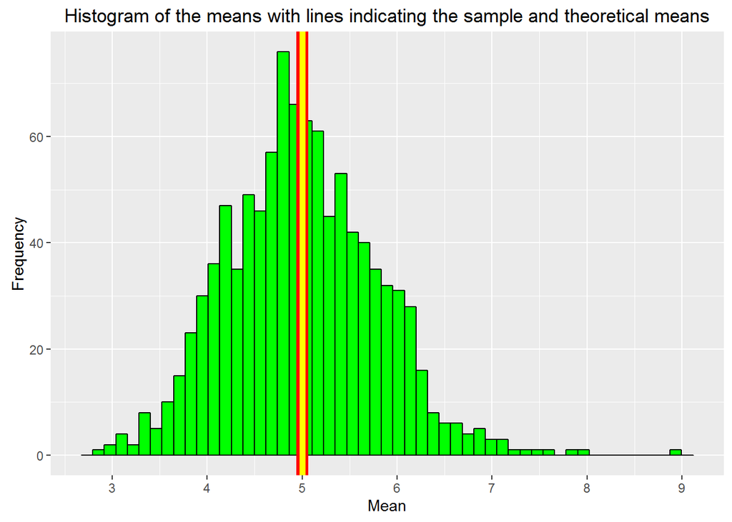

```r
ggplot(data = means, aes(x = means)) +
  geom_histogram(bins = 50, fill = "green", colour = "black") +
  scale_x_continuous(breaks = 1:10) +
  xlab("Mean") +
  ylab("Frequency") +
  ggtitle("Histogram of the means with lines indicating the sample and theoretical means") +
  geom_vline(xintercept = sampleMean, colour = "red", size = 4) +
  geom_vline(xintercept = theoreticalMean, colour = "yellow", size = 2)
```

- Red line marks the sample mean value of 5.002.
- Yellow line marks the theoretical mean value of 5.000.

## Summary

- The theoretical and sample mean calcultions both closely coincide, with a difference of only 0.002.